# Homework 5 - AD

Consider the lifexp dataset in the exam project which contains information on countries from the year 2015. The variables contained in the dataset are defined as follows:

- {Status}: Development status of the country
- {Life.Expectancy}: Country’s average life expectancy in years
- {Adult.Mortality}: Number of deaths of people between 15 and 60 per 1000 population
- {infant.deaths}: Number of infant deaths per 1000 population
- {Measles}: Number of measles cases per 1000 population
- {BMI}: average BMI for entire population
- {under.five.deaths}: Number of Under five deaths per 1000 population
- {Polio}: Polio immunization coverage for 1 year olds
- {Diptheria}: Diphtheria tetanus toxoid and pertussis immunization coverage for 1 year olds
- {HIV.AIDS}: Deaths per 1000 live births from HIV/AIDS (0-4 year olds)
- {Income.composition.of.resources}: Human Development Index in terms of income composition of resources (from 0 to 1)
- {Schooling}: Number of Years of Schooling

We are interested in creating a regression model that predicts a country’s life expectancy based on the other factors in the dataset. More specifically, we would like to determine the “best” overall prediction model for life expectancy using all of the other variables in our dataset as predictors.

- 1. Should we include any interaction or polynomial terms in our maximum model? Explain your reasoning.

     Yes we should include both polynomial and interaction terms in our maximum model. Scatterplots showed clear curvature for variables like infant.deaths, under.five.deaths, Polio, Diphtheria, and HIV.AIDS, so squared terms were added to capture these nonlinear relationships. Several interactions, especially those involving status and socioeconomic factors like Income.composition.of.resources and Schooling, also appeared to have different effects and proved to be statistically significant using the both ways step function using AIC as criterion for inclusion in the model.

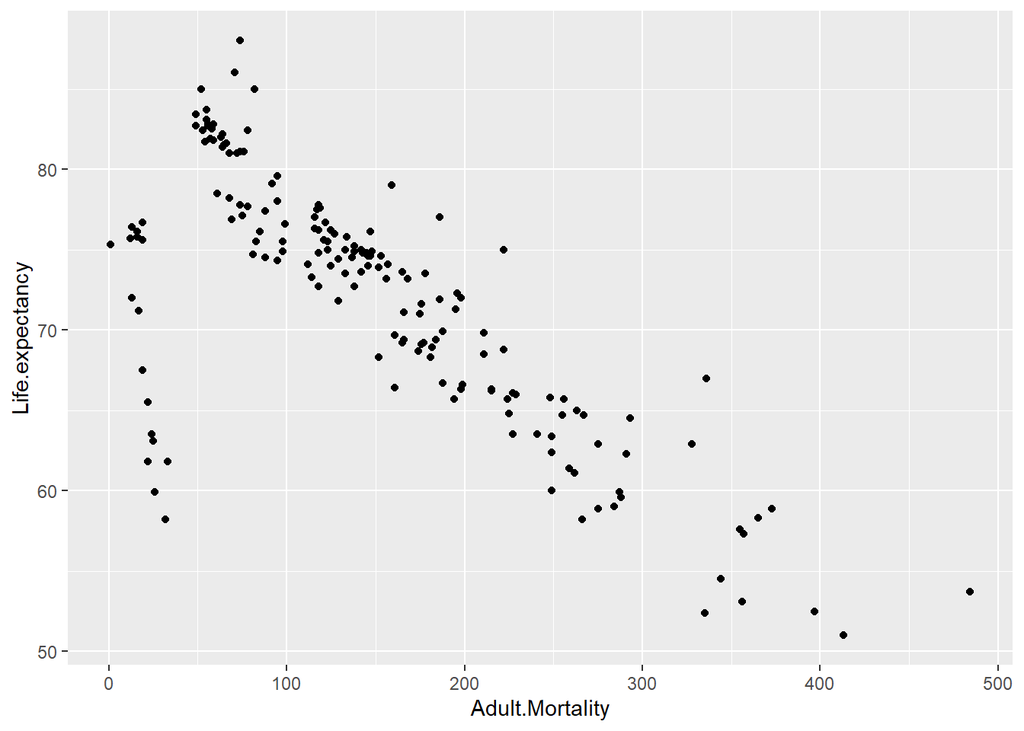

```r
library(tidyverse)
health <- read.csv("Data/lifeexp.csv")

# Scatterplots to see if we need to include a polynomial term

# Adult.Mortality - Linear
ggplot(health, aes(x = Adult.Mortality, y = Life.expectancy)) +
  geom_point()
```

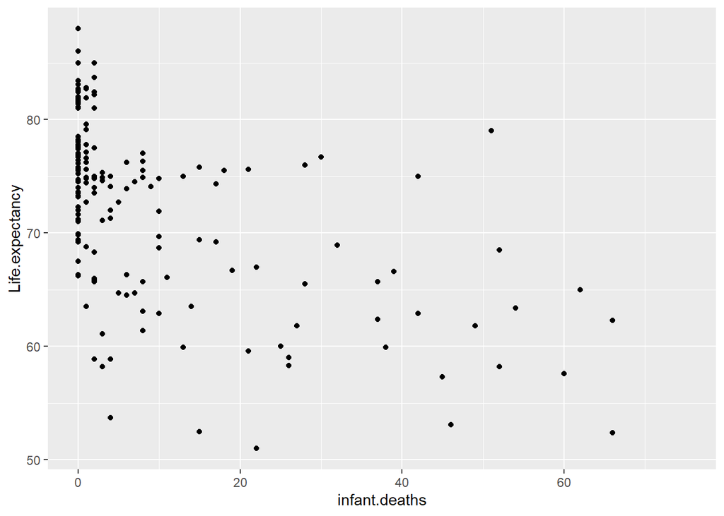

```r
# infant.deaths - Polynomial
ggplot(health, aes(x = infant.deaths, y = Life.expectancy)) +
  geom_point()+
  xlim(0,75)
```

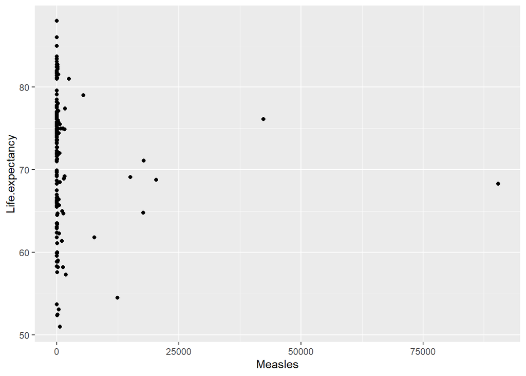

```r
# Measles - no relationship
ggplot(health, aes(x = Measles, y = Life.expectancy)) +
  geom_point()
```

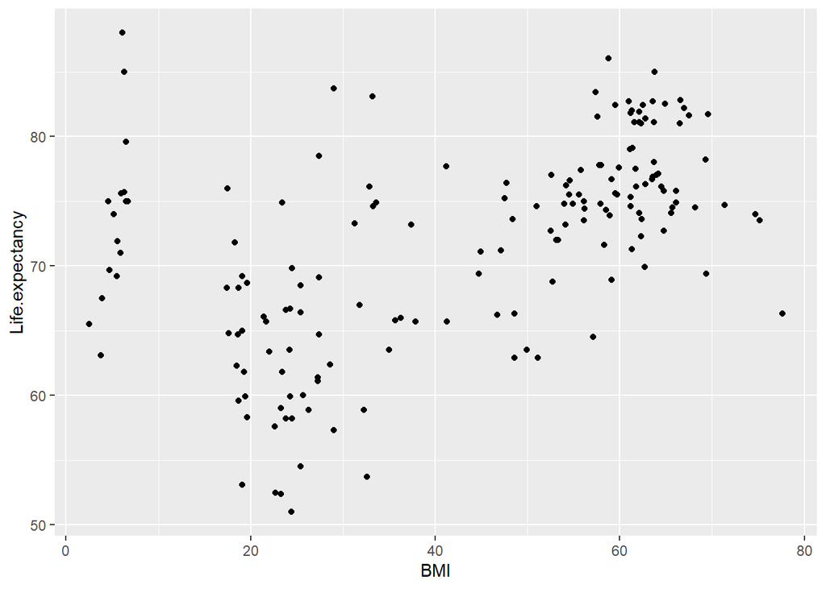

```r
# BMI - Linear
ggplot(health, aes(x = BMI, y = Life.expectancy)) +
  geom_point()
```

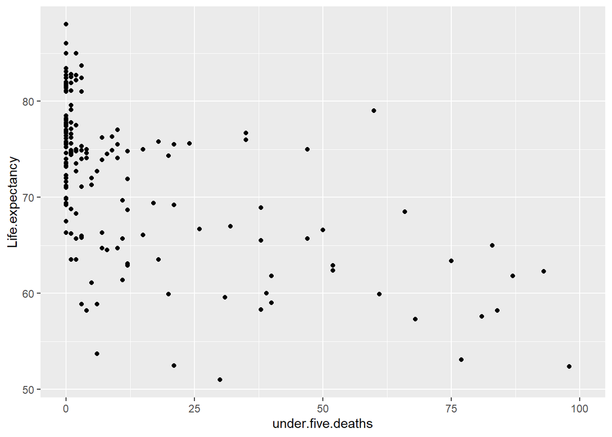

```r
# under.five.deaths - Polynomial
ggplot(health, aes(x = under.five.deaths, y = Life.expectancy)) +
  geom_point()+
  xlim(0,100)
```

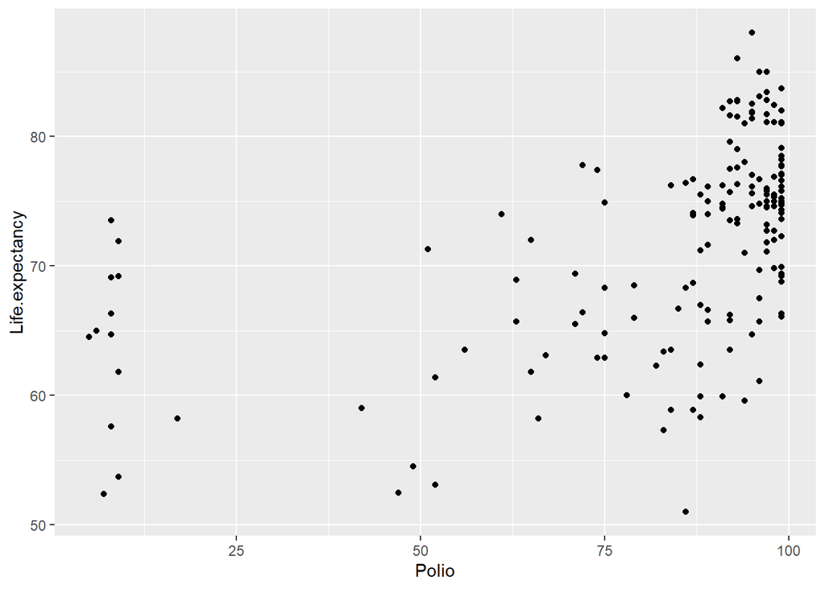

```r
# Polio - Polynomial
ggplot(health, aes(x = Polio, y = Life.expectancy)) +
  geom_point()
```

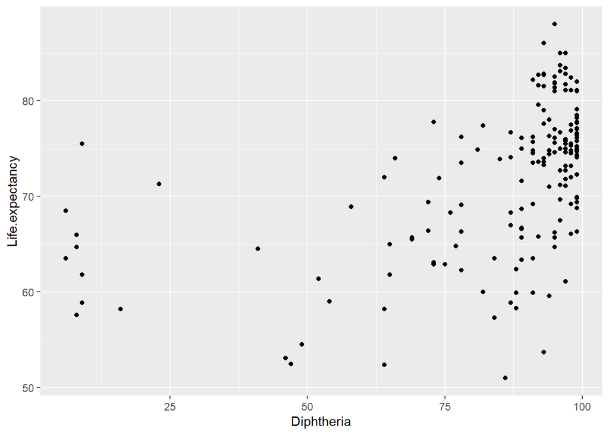

```r
# Diphtheria - Polynomial
ggplot(health, aes(x = Diphtheria, y = Life.expectancy)) +
  geom_point()
```

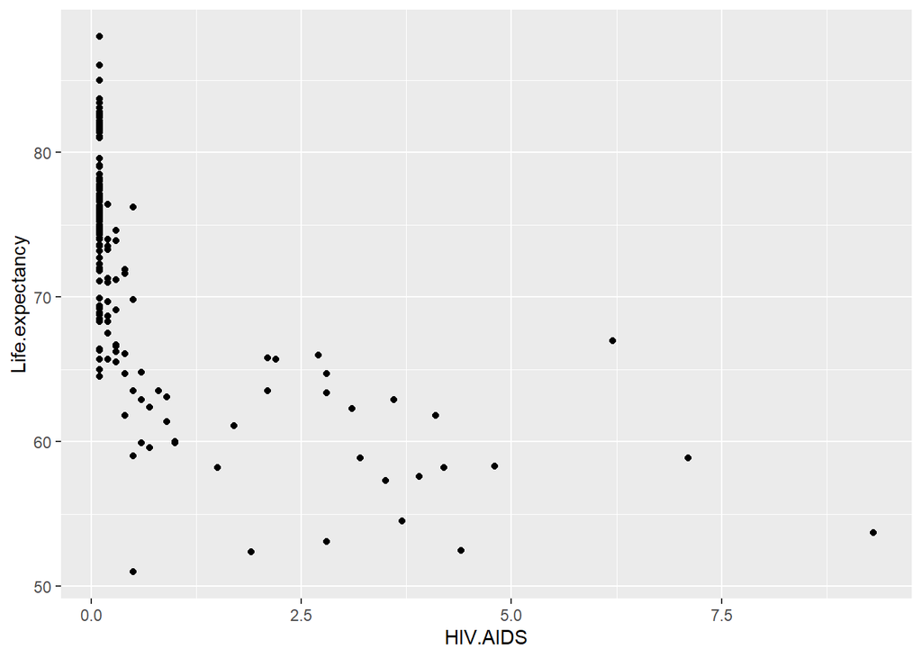

```r
# HIV.AIDS - Polynomial
ggplot(health, aes(x = HIV.AIDS, y = Life.expectancy)) +
  geom_point()
```

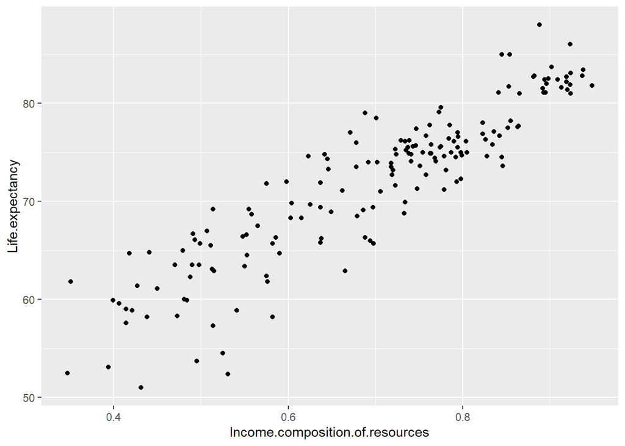

```r
# Income.composition.of.resources - Linear
ggplot(health, aes(x = Income.composition.of.resources, y = Life.expectancy)) +
  geom_point()
```

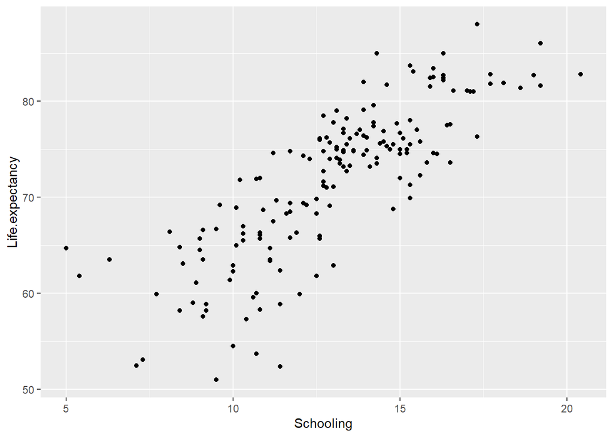

```r
# Schooling - Linear
ggplot(health, aes(x = Schooling, y = Life.expectancy)) +
  geom_point()
```

```r
mod_max <- lm(Life.expectancy ~ .*. + I(infant.deaths^2) + I(under.five.deaths^2) + I(Polio^2) +I(Diphtheria^2) + I(HIV.AIDS^2), health)

mod_best <- step(mod_max, direction = "both", trace = 0)
summary(mod_best)
```

```
Call:
lm(formula = Life.expectancy ~ Status + Adult.Mortality + infant.deaths +
    Measles + BMI + under.five.deaths + Polio + Diphtheria +
    HIV.AIDS + Income.composition.of.resources + Schooling +
    I(infant.deaths^2) + I(under.five.deaths^2) + I(Polio^2) +
    I(Diphtheria^2) + I(HIV.AIDS^2) + Status:Adult.Mortality +
    Status:Measles + Status:Diphtheria + Adult.Mortality:Measles +
    Adult.Mortality:Polio + Adult.Mortality:Income.composition.of.resources +
    infant.deaths:BMI + infant.deaths:under.five.deaths + infant.deaths:Polio +
    infant.deaths:Diphtheria + Measles:BMI + Measles:Polio +
    Measles:Diphtheria + BMI:under.five.deaths + BMI:Polio +
    BMI:Schooling + under.five.deaths:Polio + under.five.deaths:Diphtheria +
    under.five.deaths:HIV.AIDS + under.five.deaths:Income.composition.of.resources +
    under.five.deaths:Schooling + Polio:HIV.AIDS + Polio:Schooling +
    Diphtheria:Income.composition.of.resources + Diphtheria:Schooling +
    HIV.AIDS:Income.composition.of.resources + Income.composition.of.resources:Schooling,
    data = health)

Residuals:
    Min      1Q  Median      3Q     Max
-5.4318 -1.1224 -0.0374  1.0342  6.8711

Coefficients:
                                                    Estimate Std. Error t value
(Intercept)                                        1.053e+01  1.926e+01   0.547
StatusDeveloping                                   3.033e+01  1.709e+01   1.775
Adult.Mortality                                   -4.421e-02  2.268e-02  -1.950
infant.deaths                                     -1.289e+00  5.681e-01  -2.269
Measles                                            3.939e-03  1.220e-03   3.229
BMI                                                1.849e-01  7.979e-02   2.318
under.five.deaths                                  9.044e-01  4.004e-01   2.259
Polio                                              2.651e-01  1.361e-01   1.948
Diphtheria                                         5.615e-01  2.206e-01   2.545
HIV.AIDS                                          -1.828e+00  1.691e+00  -1.081
Income.composition.of.resources                    2.834e+01  1.972e+01   1.437
Schooling                                         -1.496e+00  9.354e-01  -1.599
I(infant.deaths^2)                                -7.496e-02  1.950e-02  -3.844
I(under.five.deaths^2)                            -4.088e-02  1.056e-02  -3.869
I(Polio^2)                                         1.456e-03  7.622e-04   1.911
I(Diphtheria^2)                                   -1.349e-03  8.889e-04  -1.518
```

[output cut: 64 more lines]

```
under.five.deaths:HIV.AIDS                        0.172657
under.five.deaths:Income.composition.of.resources 0.093701 .
under.five.deaths:Schooling                       0.002614 **
Polio:HIV.AIDS                                    6.53e-08 ***
Polio:Schooling                                   0.005510 **
Diphtheria:Income.composition.of.resources        0.000828 ***
Diphtheria:Schooling                              0.036922 *
HIV.AIDS:Income.composition.of.resources          0.014638 *
Income.composition.of.resources:Schooling         3.14e-06 ***
---
Signif. codes:  0 '***' 0.001 '**' 0.01 '*' 0.05 '.' 0.1 ' ' 1

Residual standard error: 2.074 on 127 degrees of freedom
Multiple R-squared:  0.9482,    Adjusted R-squared:  0.9307
F-statistic: 54.11 on 43 and 127 DF,  p-value: < 2.2e-16
```

- 2. Using the maximum model you used in (a) backward selection with Mallow’s $C_p$ as your decision criteria to eliminate variables from your model.

```r
library(leaps)

var_sel <- regsubsets(Life.expectancy ~ .*. + I(infant.deaths^2) + I(under.five.deaths^2) + I(Polio^2) +I(Diphtheria^2) + I(HIV.AIDS^2), health, method='backward', nvmax = 100, really.big = TRUE)
```

```
Reordering variables and trying again:
```

```r
which.min(summary(var_sel)$cp)
```

```
[1] 32
```

```r
coef(var_sel,32)
```

```
                          (Intercept)                      StatusDeveloping
                         4.417810e+01                          1.004789e+01
                                  BMI                            Diphtheria
                         1.662361e-01                          2.654130e-01
                   I(infant.deaths^2)                I(under.five.deaths^2)
                         1.417595e-04                         -1.035775e-04
                           I(Polio^2)                       I(Diphtheria^2)
                        -9.057523e-04                          7.339905e-04
                        I(HIV.AIDS^2)              StatusDeveloping:Measles
                         1.242638e-01                          2.793471e-04
          StatusDeveloping:Diphtheria                   Adult.Mortality:BMI
                        -1.169754e-01                         -4.523973e-05
    Adult.Mortality:under.five.deaths            Adult.Mortality:Diphtheria
                        -4.515386e-05                         -2.792253e-04
            Adult.Mortality:Schooling                     infant.deaths:BMI
                         9.338131e-05                         -1.657630e-04
                  infant.deaths:Polio              infant.deaths:Diphtheria
                         5.638641e-04                          4.172790e-03
               infant.deaths:HIV.AIDS                           Measles:BMI
                         4.594139e-02                         -1.695932e-06
            Measles:under.five.deaths                         Measles:Polio
                        -1.229914e-07                         -3.446691e-06
                     Measles:HIV.AIDS                        BMI:Diphtheria
                         6.068041e-04                         -2.141491e-03
                         BMI:HIV.AIDS                         BMI:Schooling
                        -2.517220e-02                          2.335479e-03
         under.five.deaths:Diphtheria            under.five.deaths:HIV.AIDS
                        -3.705068e-03                         -1.881690e-02
                     Polio:Diphtheria Polio:Income.composition.of.resources
                        -7.817039e-04                          2.623224e-01
                  Diphtheria:HIV.AIDS                    HIV.AIDS:Schooling
                         8.608246e-04                          1.365585e-01
            StatusDeveloping:HIV.AIDS
                        -2.442272e+00
```

- 3. Write your final regression model for predicting life expectancy.

```r
final_model <- lm(
  Life.expectancy ~
    Status +
    BMI +
    Diphtheria +
    I(infant.deaths^2) +
    I(under.five.deaths^2) +
    I(Polio^2) +
    I(Diphtheria^2) +
    I(HIV.AIDS^2) +
    Status:Measles +
    Status:Diphtheria +
    Status:HIV.AIDS +
    Adult.Mortality:BMI +
    Adult.Mortality:under.five.deaths +
    Adult.Mortality:Diphtheria +
    Adult.Mortality:Schooling +
    infant.deaths:BMI +
    infant.deaths:Polio +
    infant.deaths:Diphtheria +
    infant.deaths:HIV.AIDS +
    Measles:BMI +
    Measles:under.five.deaths +
    Measles:Polio +
    Measles:HIV.AIDS +
    BMI:Diphtheria +
    BMI:HIV.AIDS +
    BMI:Schooling +
    under.five.deaths:Diphtheria +
    under.five.deaths:HIV.AIDS +
    Polio:Diphtheria +
    Polio:Income.composition.of.resources +
    Diphtheria:HIV.AIDS +
    HIV.AIDS:Schooling,
    health
)
```

- 4. Determine if the assumptions of homoscedasticity and normally distributed residuals is violated. If one is violated, suggest a transformation of the response variable.

     None of the assumptions are violated, therefore no transformations of the response variable would be needed.

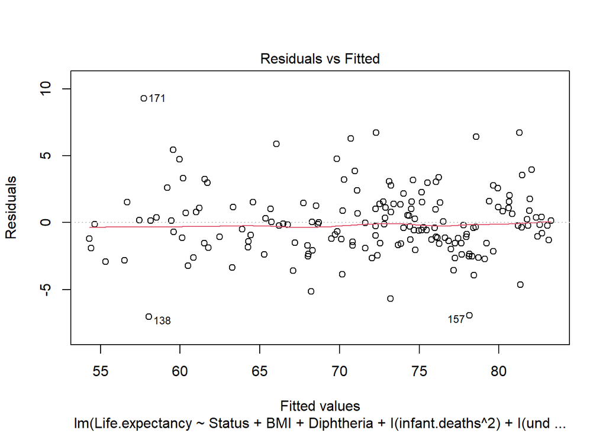

```r
library(lmtest)
plot(final_model,1)
```

```r
bptest(final_model)
```

```
    studentized Breusch-Pagan test

data:  final_model
BP = 24.138, df = 33, p-value = 0.8693
```

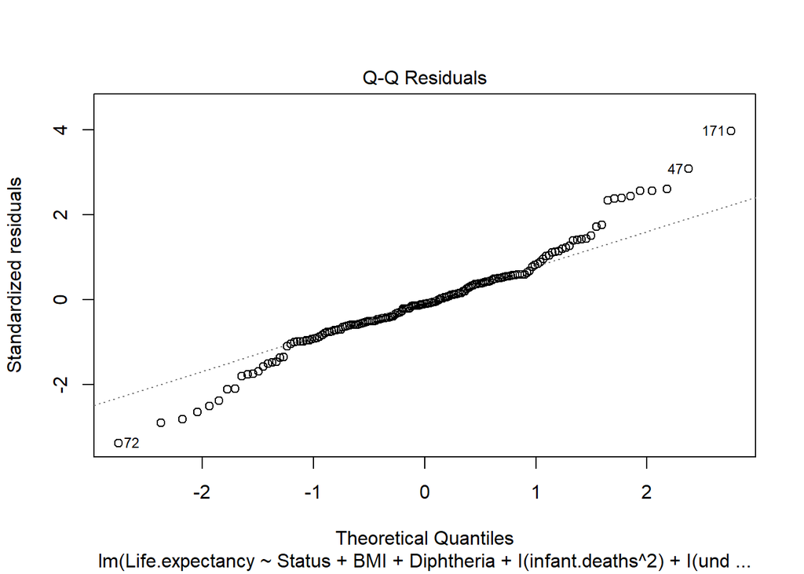

```r
plot(final_model,2)
```

```r
ks.test(rstandard(final_model),"pnorm")
```

```
    Asymptotic one-sample Kolmogorov-Smirnov test

data:  rstandard(final_model)
D = 0.094396, p-value = 0.09495
alternative hypothesis: two-sided
```